# Lesson 6: Essay Writer

[figure not shown]

### Essay Writer AI Agent Workflow

To build an AI essay writer using **LangGraph** and **Tavily**, the process is broken into several steps:

1. **Generate Plan**: The AI first creates an outline or plan for the essay. This is done only once at the beginning.
2. **Research**: The AI calls **Tavily** to gather documents relevant to the essay topic. These documents will serve as the foundation for writing.
3. **Generate Essay**: Using the plan and the documents gathered, the AI writes the initial draft of the essay.
4. **Reflection and Critique**:
   - If the essay is not complete, the AI enters a **reflect node** where it generates a critique of the current draft.
5. **Additional Research**: Based on the critique, the AI calls **Tavily** again for more documents, appending them to the existing set.
6. **Regenerate**: With the new documents, the AI goes back to the generation step and continues writing the essay.
7. **Iterative Loop**: This loop of **reflection**, **research**, and **generation** continues until a certain completion criteria is met, at which point the essay is finished.

The process repeats, refining the essay at each iteration until the desired outcome is achieved.

```python
from dotenv import load_dotenv

_ = load_dotenv()
```

```python
from langgraph.graph import StateGraph, END
from typing import TypedDict, Annotated, List
import operator
from langgraph.checkpoint.sqlite import SqliteSaver
from langchain_core.messages import AnyMessage, SystemMessage, HumanMessage, AIMessage, ChatMessage

memory = SqliteSaver.from_conn_string(":memory:")
```

```python
class AgentState(TypedDict):
    task: str # Human input - the essay we want to write about
    plan: str # Generated by planner agent
    draft: str # Draft of the essay
    critique: str # the critique agent will populate the key
    content: List[str] # The key to keep track of the list of documents fomr Tavily
    revision_number: int # number of revision
    max_revisions: int # the maximum revision we want to make
```

```python
from langchain_openai import ChatOpenAI
model = ChatOpenAI(model="gpt-3.5-turbo", temperature=0)
```

```python
# For write out a plan
PLAN_PROMPT = """You are an expert writer tasked with writing a high level outline of an essay. \
Write such an outline for the user provided topic. Give an outline of the essay along with any relevant notes \
or instructions for the sections."""
```

```python
# For one that writing the plan given the research
WRITER_PROMPT = """You are an essay assistant tasked with writing excellent 5-paragraph essays.\
Generate the best essay possible for the user's request and the initial outline. \
If the user provides critique, respond with a revised version of your previous attempts. \
Utilize all the information below as needed:

------

{content}"""
```

```python
# To control how we critiquing the draft of the essy
REFLECTION_PROMPT = """You are a teacher grading an essay submission. \
Generate critique and recommendations for the user's submission. \
Provide detailed recommendations, including requests for length, depth, style, etc."""
```

```python
# Doing research after a plan
# Generate a list of queries to pass to Tavily.
RESEARCH_PLAN_PROMPT = """You are a researcher charged with providing information that can \
be used when writing the following essay. Generate a list of search queries that will gather \
any relevant information. Only generate 3 queries max."""
```

```python
# Generate a list of queries to pass to Tavily.
# Slightly different to the planning prompt
RESEARCH_CRITIQUE_PROMPT = """You are a researcher charged with providing information that can \
be used when making any requested revisions (as outlined below). \
Generate a list of search queries that will gather any relevant information. Only generate 3 queries max."""
```

```python
from langchain_core.pydantic_v1 import BaseModel

class Queries(BaseModel):
    queries: List[str]
```

```python
# We're going to import the Tavily client instead of the tool, because we're working with it in a slightly unconventional way.
from tavily import TavilyClient
import os
tavily = TavilyClient(api_key=os.environ["TAVILY_API_KEY"])
```

## Create nodes (a.k.a Agents)

```python
def plan_node(state: AgentState):

    messages = [
        SystemMessage(content=PLAN_PROMPT),
        HumanMessage(content=state['task'])
    ]
    response = model.invoke(messages)
    return {"plan": response.content} # Update the plan key to be this response
```

```python
def research_plan_node(state: AgentState):

    """
    And so this is basically saying that the response of what
    we're going to invoke this with is going to be that pydantic object that we had, which has that list of queries.
    So we're going to call invoke and we're going to call
    invoke on a list of messages.
    """
    queries = model.with_structured_output(Queries).invoke([
        SystemMessage(content=RESEARCH_PLAN_PROMPT),
        HumanMessage(content=state['task'])
    ]) # this will genertae the quesies based on the task

    content = state['content'] or []
    for q in queries.queries:
        response = tavily.search(query=q, max_results=2)
        for r in response['results']:
            content.append(r['content'])

    # We're then going to return this content key equal to the content that is
    # the result of the original content, plus the accumulated content.
    return {"content": content}
```

```python
def generation_node(state: AgentState):

    """
    We have done a plan and research above, and now we'll write the first draft
    """

    content = "\n\n".join(state['content'] or [])
    user_message = HumanMessage(
        content=f"{state['task']}\n\nHere is my plan:\n\n{state['plan']}")

    messages = [
        SystemMessage(
            content=WRITER_PROMPT.format(content=content)
        ),
        user_message
        ]
    response = model.invoke(messages)

    # Update state to store the draft
    return {
        "draft": response.content,
        "revision_number": state.get("revision_number", 1) + 1
    }
```

```python
def reflection_node(state: AgentState):
    messages = [
        SystemMessage(content=REFLECTION_PROMPT),
        HumanMessage(content=state['draft'])
    ]
    response = model.invoke(messages)
    # Update state to store the generated critique
    return {"critique": response.content}
```

```python
def research_critique_node(state: AgentState):
    """
    take the critique generated before and do some researches
    """
    queries = model.with_structured_output(Queries).invoke([
        SystemMessage(content=RESEARCH_CRITIQUE_PROMPT),
        HumanMessage(content=state['critique'])
    ])
    content = state['content'] or []
    for q in queries.queries:
        response = tavily.search(query=q, max_results=2)
        for r in response['results']:
            content.append(r['content'])
    return {"content": content}
```

```python
def should_continue(state):
    """
    This function will run after the generation step, it either go to the critique loop or finish
    """
    if state["revision_number"] > state["max_revisions"]:
        return END
    return "reflect"
```

## Create the graph

```python
builder = StateGraph(AgentState)
```

```python
builder.add_node("planner", plan_node)
builder.add_node("generate", generation_node)
builder.add_node("reflect", reflection_node)
builder.add_node("research_plan", research_plan_node)
builder.add_node("research_critique", research_critique_node)
```

```python
builder.set_entry_point("planner")
```

```python
builder.add_edge("planner", "research_plan")
builder.add_edge("research_plan", "generate")

builder.add_conditional_edges(
    "generate",
    should_continue,
    {END: END, "reflect": "reflect"} # A switch case to get the output from should_continue()
)


builder.add_edge("reflect", "research_critique")
builder.add_edge("research_critique", "generate")
```

```python
graph = builder.compile(checkpointer=memory)
```

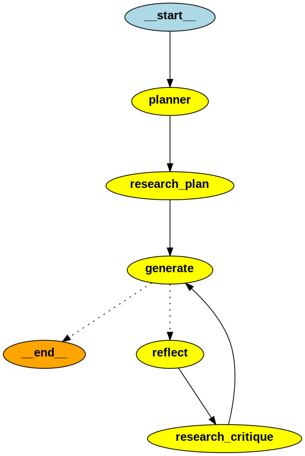

```python
from IPython.display import Image

Image(graph.get_graph().draw_png())
```

```python
thread = {"configurable": {"thread_id": "1"}}
for s in graph.stream({
    'task': "what is the difference between langchain and langsmith",
    "max_revisions": 2,
    "revision_number": 1,
}, thread):
    print(s)
```

```
{'planner': {'plan': 'I. Introduction\n    A. Brief overview of Langchain and Langsmith\n    B. Thesis statement: Exploring the differences between Langchain and Langsmith\n\nII. Langchain\n    A. Definition and explanation\n    B. Key features and characteristics\n    C. Use cases and applications\…
{'research_plan': {'content': ['This report aims to provide a detailed analysis of the difference between LangChain and LangSmith based on the information available from various sources. LangChain: A Language Model Software Tool for Prototyping. LangChain is a language model software tool that is pr…
{'generate': {'draft': "**Essay:**\n\n**I. Introduction**\n\nLangChain and LangSmith are two distinct tools in the realm of language model software, each serving unique purposes in the development process. This essay aims to delve into the disparities between LangChain and LangSmith, shedding light …
```

```
{'reflect': {'critique': "**Critique:**\n\nThe essay provides a clear and structured comparison between LangChain and LangSmith, outlining their key features, advantages, and drawbacks effectively. The introduction sets the stage for the discussion, and the conclusion effectively summarizes the main…
{'research_critique': {'content': ['This report aims to provide a detailed analysis of the difference between LangChain and LangSmith based on the information available from various sources. LangChain: A Language Model Software Tool for Prototyping. LangChain is a language model software tool that i…
```

```
{'generate': {'draft': "**Essay:**\n\n**I. Introduction**\n\nLangChain and LangSmith are two distinct tools in the realm of language model software, each serving unique purposes in the development process. LangChain is tailored for early-stage prototyping and small-scale applications, while LangSmit…
```

So we can see that it generates a plan.

LangChain versus LangSmith. We can see some more details on what LangChain is, what LangSmith is. Some talk about scalability, incorruptibility, performance.

We've now created this writer agent. This is a great time to go back and try it out with different questions. Maybe have it write a few different revisions, see how it performs, mess around with the prompts. There's a lot that you can change here to see how this overall writing agent responds. We built a little GUI that you can use to try out the Essay Generator.

## Essay Writer Interface

```python
import warnings
warnings.filterwarnings("ignore")

from helper import ewriter, writer_gui
```

```python
MultiAgent = ewriter()
app = writer_gui(MultiAgent.graph)
app.launch()
```

```
Running on local URL:  http://0.0.0.0:8080
Running on public URL: https://75b9ed5ba5df4cc871.gradio.live

This share link expires in 72 hours. For free permanent hosting and GPU upgrades, run `gradio deploy` from Terminal to deploy to Spaces (https://huggingface.co/spaces)
```

[interactive chart not shown]